# Visualizing the Nobel Gender Gap

# Introduction

This project explores gender disparities among recipients of the Nobel Prize. The dataset ([source](https://github.com/rfordatascience/tidytuesday/tree/master/data/2019/2019-05-14)) contains all chemistry, physics, medicine, economics, literature, and peace prize laureates from its first year in 1901 through 2016. Since no prizes were awarded during the Nazi occupation of Norway from 1940 - 1942, this dataset covers 113 award years total.

In that time frame, there were 881 unique laureates. Let’s see how that number breaks down by gender.

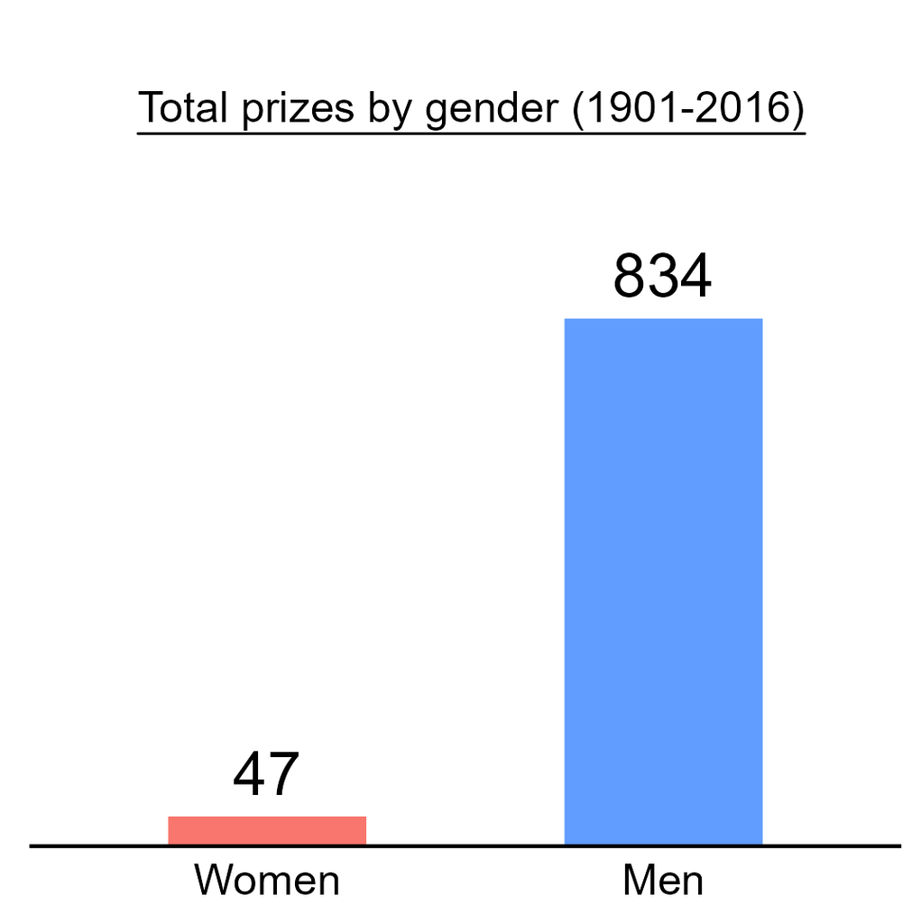

Clearly, the gender gap is vast, with women only making up 5% of all laureates in 113 years!

# Prize Category

Let’s see how this disparity breaks down by prize category. In the figure below, the number of male and female laureates are plotted for each category, with the size of the gender gap represented by the width of line that separates them.

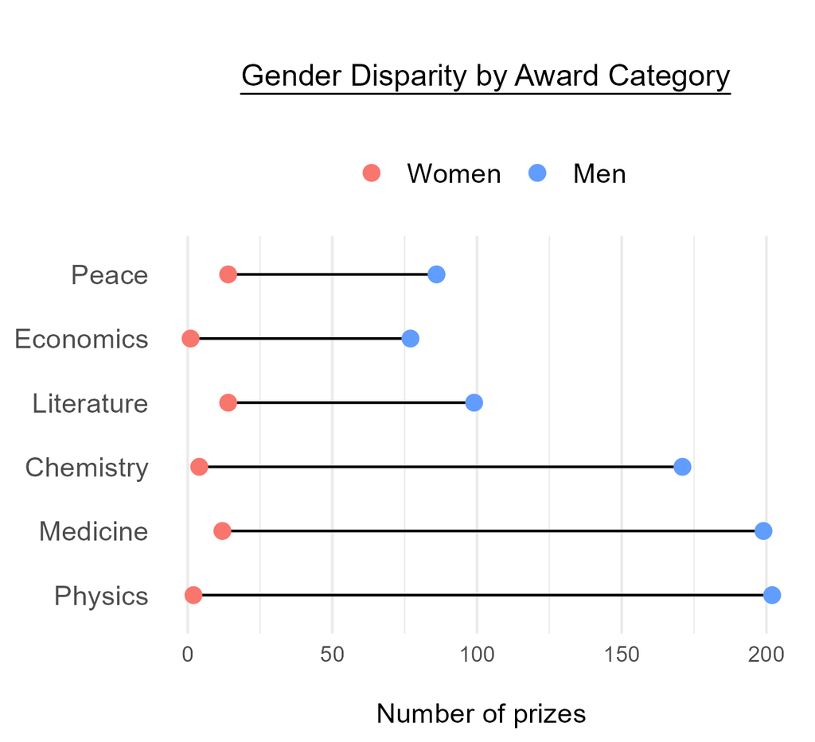

While the gap between men and women is smaller in the Peace, Economics, and Literature categories compared to the Chemistry, Medicine, and Physics prizes, this doesn’t appear to be due to higher rates of awards going to women; rather rather, the total number of prizes for those categories *overall* is smaller. In other words, instead of women winning more prizes in those areas, men have simply won fewer.

# Awards over Time

The first Nobel Prize was awarded in 1901, which was 19 years before women even had the right to vote. Perhaps women laureates have become more common in recent years. Let’s see how award numbers for women and men have changed over the past century.

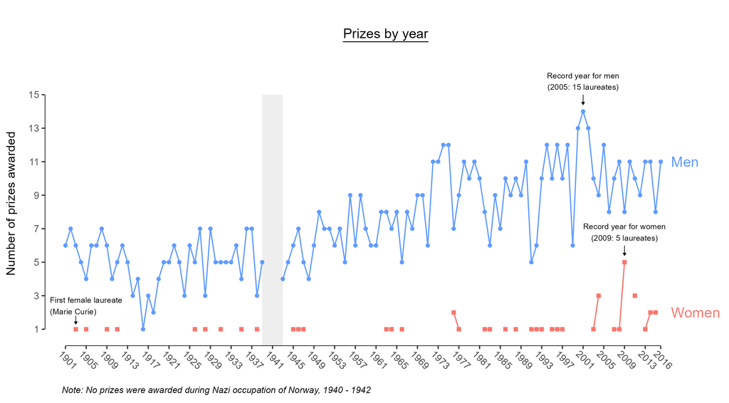

While the number of male winners has steadily increased over the past hundred years, the rate of female laureates has been mostly flat, with a possible uptick in the past 15 years or so.

The below figure plots the proportion of laureates that were men each year. Years where 100% of the laureates were men are shaded in red, while years that had at least one female laureate are shaded in green.

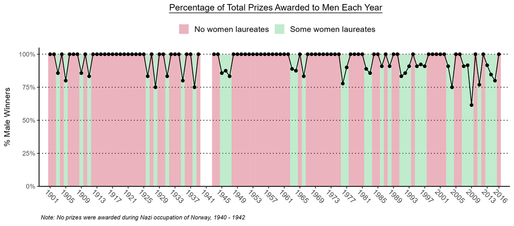

As the preponderance of red shows, in the 113 years covered by this dataset (which excludes the years 1940-1942, when no prizes were awarded due to the Nazi occupation of Norway), there are only 36 years where at least one woman received a Nobel–just 32% of the time! That means that 68% of the time (77 years), 100% of the prizes went to men!

The longest stretch without a single female laureate was 1947 to 1963, a 16-year gap. But more recent years may give us hope: it appears that the proportion of female laureates in the latter 15 years of the dataset may be increasing, as reflected in the smoothed best fit line below.

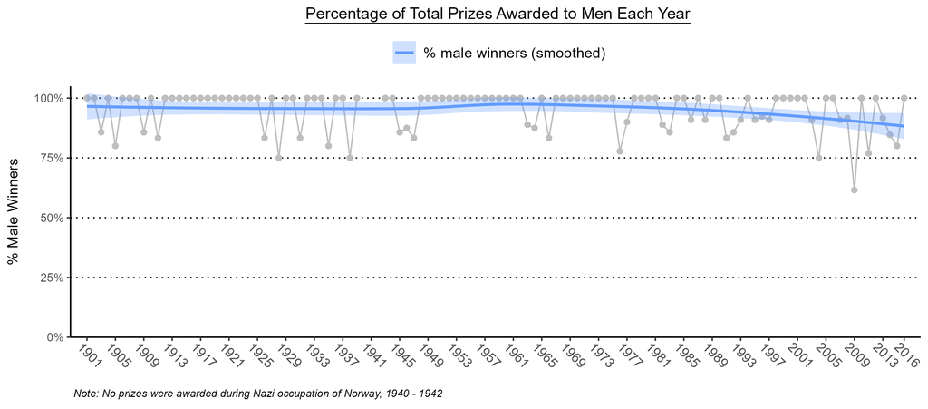

But Is this trend statistically significant? To test this, I fit a simple linear model to the above data:

$$ProportionMaleWinners \sim Year$$

# Geographic Distribution

Just for fun, I’ll conclude this exploration with a visualization of the geographic distribution of male and female laureates by birth country!

[interactive chart not shown]

Back to portfolio